# Report about the London Weather

Hannah Westerhaus

June 2022

### Abstract

This report is for my dear friend in order to convince her to stay in the warm and sunny South Africa.

Dear Friend,

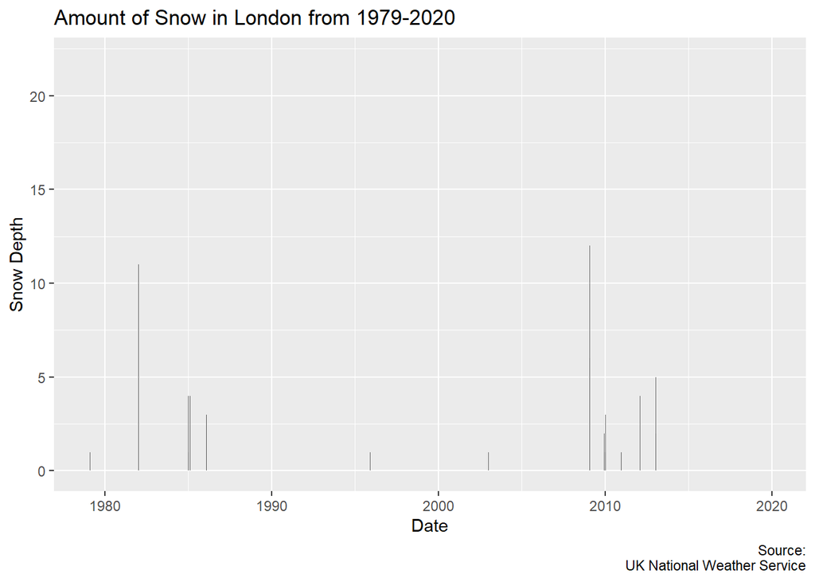

Figure 1: Snow Depth in London.

Now to relieve you of some of your fears that have surely surfaced after this first graph, let me calm you down by presenting you with the hours of sunshine in 2020. Please take careful note of the winter months…Just imagine lockdown in London.

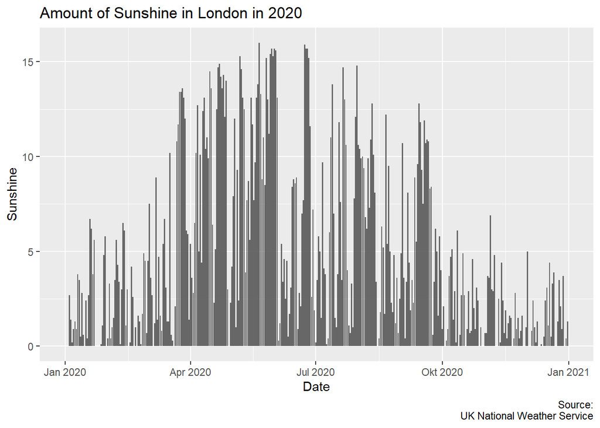

Figure 2: Sunshine in London in 2020.

As if the snow was not enough, I have highlighted for you the extensive amount of rain you will face, in every case my goodbye present for you will be an umbrella!

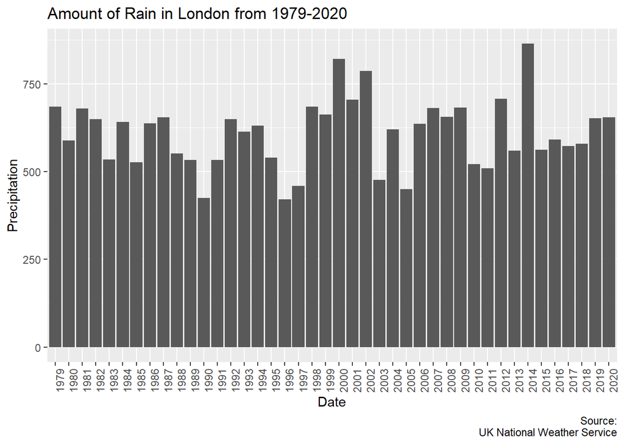

Figure 3: Rain in London.

And last but not least, please compare the average annual temperature for Cape Town (green line) and London (blue line). Please also note how many times the temperature crosses the red line, which should remind you of my first snow plot. All in all, I am sure that by now, you are fully convinced to stay in beautiful Stellenbosch and South Africa and look forward to the many days we will spend together here.

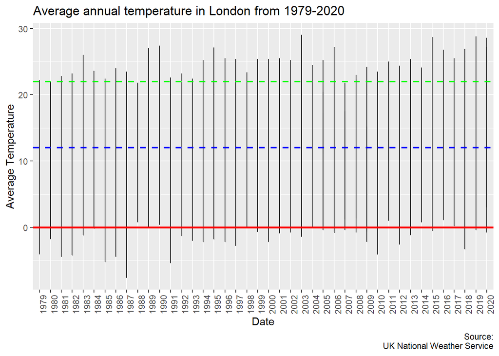

Figure 4: Temperature in London.

All in all, I am sure that by now, you are fully convinced to stay in beautiful Stellenbosch and South Africa and look forward to the many days we will spend together here.

All the best, your friend Hannah